# Summary Vignette

# Interaction Data Summary Statistics

```r
library(dplyr)
library(stringr)
set.seed(44)

df <- read.csv(here::here("../AvianMetaNetwork-Working/L1/amn_cac.csv"))
spp <- read.csv(here::here("./data/L1/species_checklists/spp_clem_in_amn_cac.csv"))


#### TAXA COUNTS ####

unique_taxa_list <- unique(c(df$taxa1_clements, df$taxa2_clements))

num_total_taxa <- length(unique_taxa_list)

total_cac_taxa <- sum(spp$canada_ak_conus)

num_non_cac_taxa <- num_total_taxa - total_cac_taxa

#### SPECIES COUNTS ####

#Removing hybrids, genera, subspecies and unidentified
total_spp <- length(spp$scientific.name[spp$category %in% c("species")])

total_spp_cac <- sum(spp$canada_ak_conus[spp$category %in% c("species")])

#### GENUS/FAMILY LEVEL COUNTS ####

total_fam_cac <- length(unique(spp$family[spp$canada_ak_conus == TRUE]))

total_fam_non_cac <-  length(unique(spp$family)) - total_fam_cac

total_ord_cac <- length(unique(spp$order[spp$canada_ak_conus == TRUE]))

total_ord_non_cac <-  length(unique(spp$order)) - total_ord_cac

total_gen <- length(unique(spp$scientific.name[spp$category %in% c("species", "subspecies")] %>%
                    word(1)))

total_gen_cac <- length(unique(spp$scientific.name[spp$canada_ak_conus == TRUE & spp$category %in% c("species", "subspecies")] %>% word(1)))

total_gen_non_cac <- total_gen - total_gen_cac



#### North American Only Interactions ####
spp_ls_cac <- spp$scientific.name[spp$canada_ak_conus == TRUE]

amn_spp1_cac <- df[df$taxa1_clements %in% spp_ls_cac,]
amn_spp_all_cac <- amn_spp1_cac[amn_spp1_cac$taxa2_clements %in% spp_ls_cac,]


#### INTERACTIONS ####

## All interactions
num_intxns <- nrow(df)

unique_intxns <- df %>%
  dplyr::select(taxa1_clements,
                taxa2_clements,
                effect_tx1_on_tx2,
                effect_tx2_on_tx1,
                interaction) %>%
  filter(!duplicated(.)) %>%
  mutate(
    # Labels taxa pairs by alphabetical order
    taxa_lo = pmin(taxa1_clements, taxa2_clements),
    taxa_hi = pmax(taxa1_clements, taxa2_clements),

    # Checks whether order is swapped (non-alphabetical)
    swapped = taxa1_clements > taxa2_clements,

    # normalize effects so they always mean:
    # eff_lo_on_hi = effect of taxa_lo on taxa_hi
    # eff_hi_on_lo = effect of taxa_hi on taxa_lo
    eff_lo_on_hi = if_else(swapped, effect_tx2_on_tx1, effect_tx1_on_tx2),
    eff_hi_on_lo = if_else(swapped, effect_tx1_on_tx2, effect_tx2_on_tx1)
  )  %>%
  distinct(taxa_lo, taxa_hi, interaction, eff_lo_on_hi, eff_hi_on_lo)

## CAC only interactions
num_intxns_cac <- nrow(amn_spp_all_cac)

unique_intxns_cac <- amn_spp_all_cac %>%
  dplyr::select(taxa1_clements,
                taxa2_clements,
                effect_tx1_on_tx2,
                effect_tx2_on_tx1,
                interaction) %>%
  filter(!duplicated(.)) %>%
  mutate(
    # Labels taxa pairs by alphabetical order
    taxa_lo = pmin(taxa1_clements, taxa2_clements),
    taxa_hi = pmax(taxa1_clements, taxa2_clements),

    # Checks whether order is swapped (non-alphabetical)
    swapped = taxa1_clements > taxa2_clements,

    # normalize effects so they always mean:
    # eff_lo_on_hi = effect of taxa_lo on taxa_hi
    # eff_hi_on_lo = effect of taxa_hi on taxa_lo
    eff_lo_on_hi = if_else(swapped, effect_tx2_on_tx1, effect_tx1_on_tx2),
    eff_hi_on_lo = if_else(swapped, effect_tx1_on_tx2, effect_tx2_on_tx1)
  )  %>%
  distinct(taxa_lo, taxa_hi, interaction, eff_lo_on_hi, eff_hi_on_lo)

pct_unique_in_cac <- round(length(unique_intxns_cac$interaction)/
                             length(unique_intxns$interaction)*100,2)

entry_changes_pct <- round(sum(!is.na(df$entry_changes))/length(df$entry_changes)*100,2)
```

### Sanity Checks

- Number of taxa in species list equals number of taxa in network: TRUE
- Percent of interactions with entry changes: 13.5%

### Taxa-level summary

- Number of taxa (total): 1989
- Number of focal taxa: 731
- Number of additional non-focal taxa: 1258

### Species-level summary

- Number of species (total): 1626
- Number of North American species: 695
- Number of additional species: 931
- Percent of world’s bird spp (out of 11,145 spp): 14.59%

### Genus/Family/Order-level summary

- Number of North American orders: 24
- Number of additional orders: 8
- Number of North American families: 81
- Number of additional families: 42
- Number of North American genera:321
- Number of additional genera: 318
- Number of total genera: 639

### Interactions summary

- Total number of interaction types: 23
- Number of documented pairwise interactions: 25907
- Number of unique pairwise interactions: 18431
- Number of unique pairwise interactions among focal taxa: 14016
- Percent of unique pairwise interactions among focal taxa: 76.05%

#### Unique taxa1/taxa2/interaction combinations by interaction type:

```r
source(here::here("./R/lib/interaction_categories_and_colors.R"))

unique_intxns %>% left_join(interaction_categories) %>% group_by(category) %>% summarize(n=n()) %>% arrange(-n)
```

```
# A tibble: 8 × 2
  category         n
  <fct>        <int>
1 Trophic       4786
2 Facilitation  4229
3 Competition   2713
4 Other         2453
5 Parasitism    2050
6 Commensalism  1212
7 Mobbing        917
8 Amenalism       71
```

#### Total interactions by type (includes repeat documentation of same taxa1/taxa2/interaction type combinations):

```r
df %>% left_join(interaction_categories) %>% group_by(category) %>% summarize(n=n()) %>% arrange(-n)
```

```
# A tibble: 8 × 2
  category         n
  <fct>        <int>
1 Trophic       6504
2 Facilitation  5922
3 Competition   4019
4 Other         3662
5 Parasitism    3149
6 Commensalism  1552
7 Mobbing       1026
8 Amenalism       73
```

# Interaction Data Exploratory Figures

Source `figure_processing.R` which contains the data processing and plotting functions. See `7_figure_processing_vignette.qmd` for further explanation of the data processing and plot functions!

```r
source(here::here("R/lib/figure_processing.R"))
```

### Interaction Distribution Figure

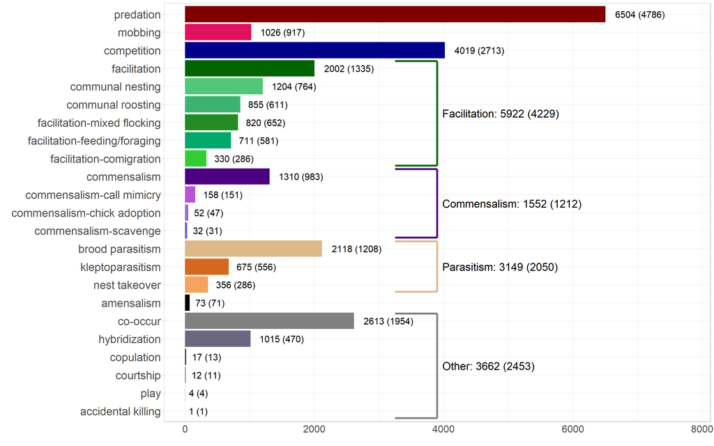

```r
#Defining the position of the brackets in the figure
bracket_data <- type_summ_total %>%
  group_by(category) %>%
  summarize(
    y_min = min(as.numeric(interaction)), #Vertical portion of brackets
    y_max = max(as.numeric(interaction)),
    n_types = n(),
    total_n = sum(total),
    total_unique = sum(unique)
  ) %>%
  filter(n_types > 1) %>%  #No brackets are needed for categories with only 1 type!
  mutate(
    y_min = y_min - 0.4,  #Shortened vertical extent
    y_max = y_max + 0.4,
    x_pos = max(type_summ$total) * 0.5,  #Position brackets to the right
    x_end = max(type_summ$total) * 0.6,  #End of bracket
    y_mid = (y_min + y_max) / 2,      #Midpoint for category label
    category_label = paste0(category, ": ", total_n, " (", total_unique, ")")
  ) %>%
  #Using color from first interaction for each category
  left_join(
    type_summ_total %>%
      group_by(category) %>%
      slice(1) %>%
      select(category, bracket_color = color),
    by = "category"
  )

ggplot(type_summ_total, aes(x = interaction, y = total, fill = interaction)) +
  theme_light() +
  geom_bar(stat = "identity") +
  scale_fill_manual(values = setNames(interaction_categories$color,
                                      interaction_categories$interaction)) +
  geom_text(aes(label = paste0(total, " (", unique, ")")), hjust = -0.2, size = 5.25) +
  #Bracket: lower bar
  geom_segment(data = bracket_data,
               aes(x = y_min, xend = y_min,
                   y = x_pos, yend = x_end, color = bracket_color),
               inherit.aes = FALSE, linewidth = 1.5) +
  #Bracket: upper bar
  geom_segment(data = bracket_data,
               aes(x = y_max, xend = y_max,
                   y = x_pos, yend = x_end, color = bracket_color),
               inherit.aes = FALSE, linewidth = 1.5) +
  #Bracket: side bar
  geom_segment(data = bracket_data,
               aes(x = y_min, xend = y_max,
                   y = x_end, yend = x_end, color = bracket_color),
               inherit.aes = FALSE, linewidth = 1.5) +
  scale_color_identity() +
  #Category labels
  geom_text(data = bracket_data,
            aes(x = y_mid, y = x_end + 80,
                label = category_label),  #Use the new label
            inherit.aes = FALSE, size = 6.25, hjust = 0) +
  theme(axis.text.x = element_text(angle = 0, size = 16),
        axis.text.y = element_text(size = 18),
        legend.position = "none") +
  xlab("") +
  ylab("") +
  coord_flip() +
  scale_y_continuous(expand = expansion(mult = c(0.05, 0.25)))
```

### Interaction Phylogeny Figure

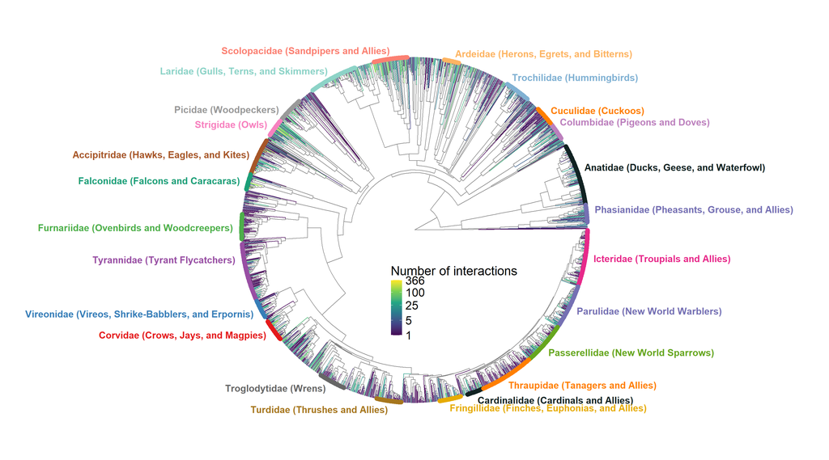

```r
plot_phylo_combined(
  tree = NA_tree,
  data = inter_NA_working,
  value_col = "n_int",
  label_offset = 5,
  label_size = 5.25,
  tip_size = 3,
  min_species = 25,
  legend_title = "Number of interactions"
)
```

### Interaction Network Figure

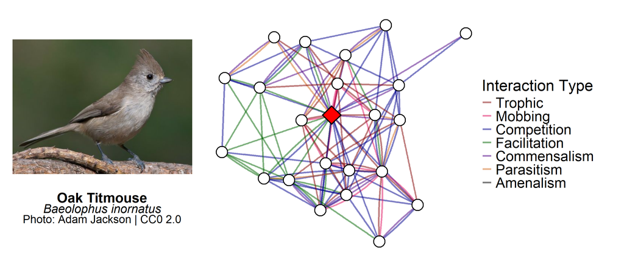

```r
set.seed(44)
create_network(inter_NA_int, "Baeolophus inornatus", curve_edges = T, show_labels = F, cats = T)
```

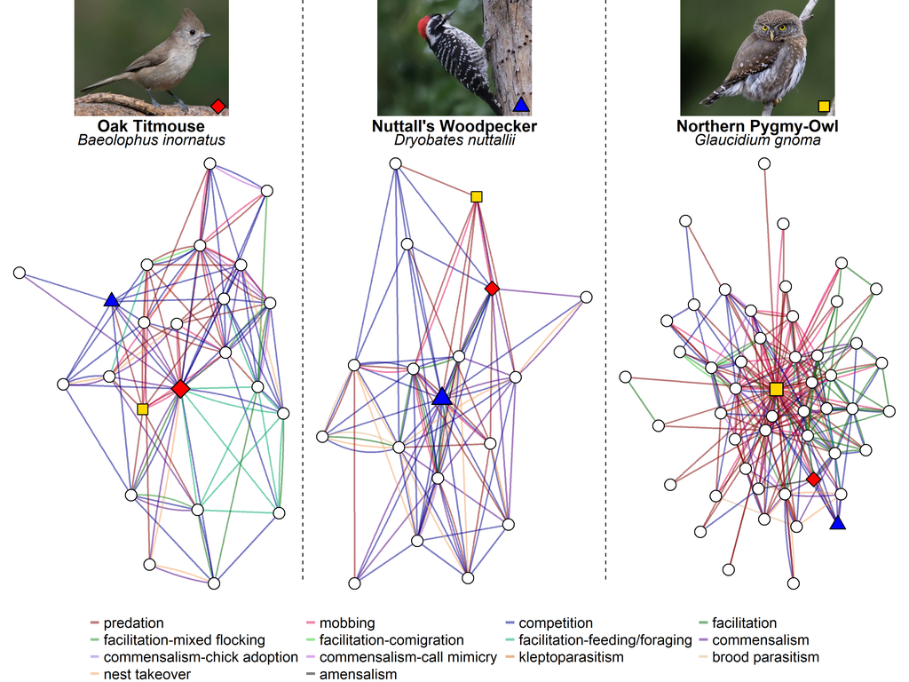

```r
set.seed(22)
create_combined_network(inter_NA_int, c("Baeolophus inornatus", "Dryobates nuttallii", "Glaucidium gnoma"), curve_edges = T, cats = F)
```

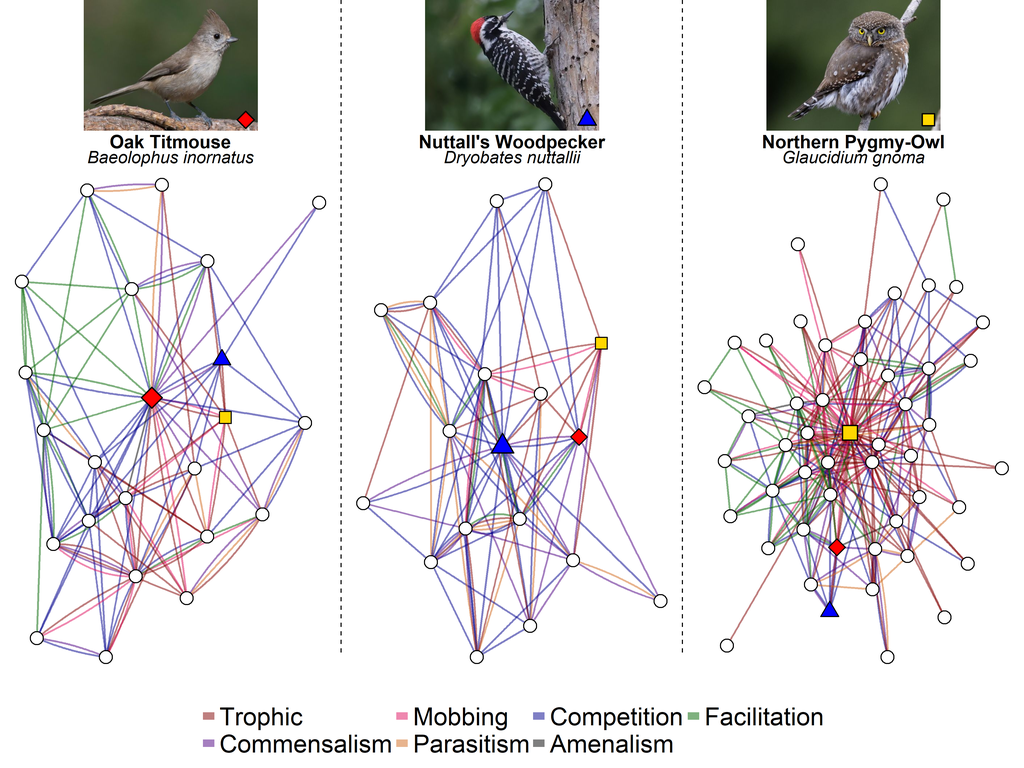

```r
set.seed(55)
create_combined_network(inter_NA_int, c("Baeolophus inornatus", "Dryobates nuttallii", "Glaucidium gnoma"), curve_edges = T, cats = T, legend_text_size = 35, legend_line_size = 5)
```